# WTI Options Portfolio: Full Greek P&L Attribution

# Question 2 (3 points)

Sum Greeks across positions to show **portfolio-level Greeks** at the current market. Present in a `gt::gt()` table. At approximately what futures price does the portfolio delta change sign?

WTI Portfolio Greeks

| S | port_delta | port_gamma | port_vega | port_theta |
| --- | --- | --- | --- | --- |
| 50 | −656,349 | −55,013 | −15,100,562 | 16,790,624 |
| 50 | −683,605 | −53,977 | −15,183,635 | 17,034,247 |
| 51 | −710,292 | −52,740 | −15,206,742 | 17,229,368 |
| 52 | −736,313 | −51,313 | −15,169,407 | 17,374,846 |
| 52 | −761,576 | −49,712 | −15,071,803 | 17,470,034 |
| 52 | −785,999 | −47,952 | −14,914,755 | 17,514,791 |
| 53 | −809,505 | −46,050 | −14,699,742 | 17,509,488 |
| 54 | −832,028 | −44,025 | −14,428,887 | 17,455,000 |
| 54 | −853,513 | −41,897 | −14,104,935 | 17,352,704 |
| 54 | −873,912 | −39,687 | −13,731,229 | 17,204,458 |
| 55 | −893,189 | −37,415 | −13,311,669 | 17,012,584 |
| 56 | −911,320 | −35,104 | −12,850,673 | 16,779,835 |
| 56 | −928,290 | −32,774 | −12,353,124 | 16,509,367 |
| 56 | −944,095 | −30,448 | −11,824,311 | 16,204,695 |
| 57 | −958,742 | −28,147 | −11,269,869 | 15,869,656 |
| 58 | −972,249 | −25,891 | −10,695,709 | 15,508,359 |
| 58 | −984,644 | −23,699 | −10,107,949 | 15,125,138 |
| 58 | −995,963 | −21,591 | −9,512,837 | 14,724,496 |
| 59 | −1,006,252 | −19,583 | −8,916,683 | 14,311,058 |
| 60 | −1,015,565 | −17,691 | −8,325,775 | 13,889,511 |
| 60 | −1,023,964 | −15,930 | −7,746,312 | 13,464,557 |
| 60 | −1,031,518 | −14,311 | −7,184,329 | 13,040,852 |
| 61 | −1,038,301 | −12,846 | −6,645,628 | 12,622,960 |
| 62 | −1,044,392 | −11,544 | −6,135,714 | 12,215,304 |
| 62 | −1,049,874 | −10,412 | −5,659,732 | 11,822,115 |
| 62 | −1,054,833 | −9,454 | −5,222,416 | 11,447,396 |
| 63 | −1,059,358 | −8,675 | −4,828,039 | 11,094,875 |
| 64 | −1,063,537 | −8,074 | −4,480,368 | 10,767,978 |
| 64 | −1,067,461 | −7,652 | −4,182,638 | 10,469,796 |
| 64 | −1,071,218 | −7,406 | −3,937,516 | 10,203,060 |

[output cut: 71 more lines]

- Because the portfolio has three positions of 2000 options each, and because they are on the same underlying, the portfolio will never have a positive delta. The reason is that the short call and long puts both have negative deltas so the short put is the only position with a positive delta and it is not large enough to make the portfolio delta positive.

# Question 3 (8 points)

Overnight, US-Iran tensions escalate sharply. The US strikes Iranian nuclear facilities; Iran retaliates by mining the Strait of Hormuz. WTI gaps up at the open:

- WTI futures: F moves from **73.00** to **90.00** (+$17.00/bbl)
- Implied volatility: each position’s sigma spikes by **+0.20** (20 vol points)
- Time: **1 calendar day** passes

For each position and for the portfolio total, compute:

1. **Actual P&L**: full revaluation at new F, new sigma, new T. P&L = (new price − old price) × n × mult.
2. **Attributed P&L**: ΔV ≈ (Delta × ΔF) + (½ × Gamma × ΔF²) + (Vega × Δσ) + (Vanna × ΔF × Δσ) + (Theta × Δt), scaled to dollars.
3. **Unexplained residual**: Actual − Attributed.
4. **Attribution breakdown**: what share (%) of Attributed P&L comes from each Greek?

**Vanna** (∂²V/∂F∂σ) measures how delta changes as volatility moves. With both a large spot jump and a large vol spike coinciding, Vanna is non-negligible. Use a central-difference cross-partial:

$$\text{Vanna} = \frac{V(F+h, \sigma+k) - V(F+h, \sigma-k) - V(F-h, \sigma+k) + V(F-h, \sigma-k)}{4 \cdot h \cdot k}$$

with h = `step_S` and k = `step_v`. The Vanna P&L contribution is Vanna × ΔF × Δσ.

Present all results in a `gt::gt()` table. Which position dominates the loss? Is the Greek attribution a reliable approximation here, and why or why not?

**P&L Attribution — WTI Options Portfolio**

| Position | P&L ($) Actual | P&L ($) Attributed | P&L ($) Residual ($) | P&L ($) Residual (%) | Attribution by Greek ($) Delta | Attribution by Greek ($) Gamma | Attribution by Greek ($) Vega | Attribution by Greek ($) Theta | Attribution by Greek ($) Vanna | % of Attributed P&L Delta | % of Attributed P&L Gamma | % of Attributed P&L Vega | % of Attributed P&L Theta | % of Attributed P&L Vanna |
| --- | --- | --- | --- | --- | --- | --- | --- | --- | --- | --- | --- | --- | --- | --- |
| P1 | −$3,042,716 | −$487,594 | −$2,555,122 | 84.0 | −$12,643,944 | $8,847,368 | $5,498,955 | −$52,221 | −$2,137,752 | 2.6% | −1.8% | −1.1% | 10.7 | 438.4 |
| P2 | $82,558 | $3,305,648 | −$3,223,091 | 3.9% | $2,408,287 | −$15,063 | −$2,008,108 | $22,699 | $2,897,833 | 72.9 | −0.5 | −60.7 | 0.7 | 87.7 |
| P3 | −$24,682,662 | −$20,232,627 | −$4,450,035 | 18.0 | −$10,083,123 | −$982,616 | −$5,033,177 | $41,126 | −$4,174,836 | 49.8 | 4.9 | 24.9 | −0.2 | 20.6 |

- Like we noted earlier, the short call option is the position that carries most of the risk and is the position that is driving most of the losses in this scenario. While the long put position also loses, it is not as nearly close to the amount that the call loses. The short put gains because the option holder will not exercise under this scenario so we can keep the option premium without having to deliver on our obligations.
- Using the greeks to approximate the P&L attribution is not very accurate because the numerical greeks were calculated when the futures price was at $73. At that price point, the long put & short call positions were both near the money, meaning that they had higher absolute deltas and vegas which is not the case after the shift in price and volatility.

# Question 4 (4 points)

The Iran war scenario (ΔF = +$17) is an extreme move. How well does the Greek approximation hold as WTI moves further from the current market?

Holding vol and time constant at their initial values, compute Actual P&L (full revaluation) and Attributed P&L (Delta + Gamma only) for the portfolio across ΔF ∈ [–20, +20] in $1 increments.

**a.** Plot Actual, Attributed, and the Residual on the same chart. Mark the Iran war move (ΔF = +17) with a vertical line.

**b.** At what ΔF does the absolute residual first exceed 5% of the absolute Actual P&L? Report in a `gt::gt()` table. What does this tell you about using Greeks for risk management in extreme scenarios?

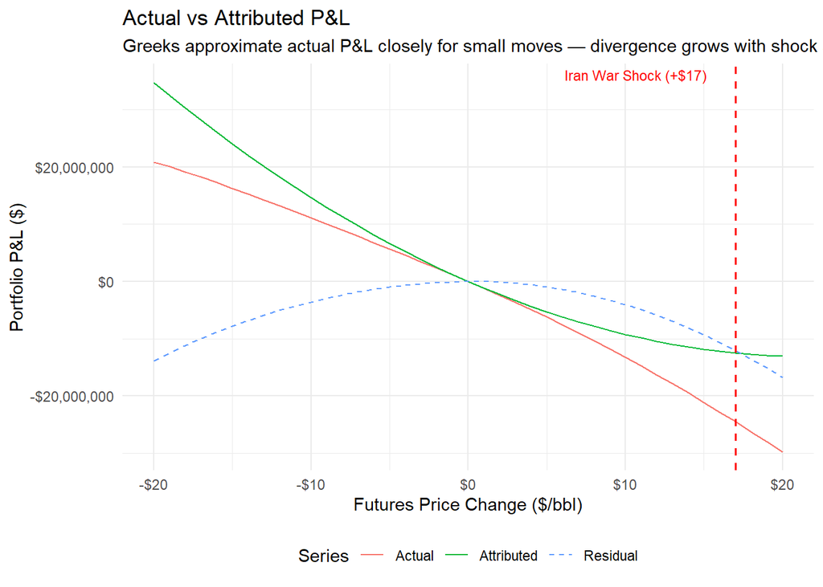

| price_grid | Actual | Residual | Residual % of Actual |
| --- | --- | --- | --- |
| -20 | $20,889,989 | −$13,879,081 | 66.44% |
| -19 | $20,038,716 | −$12,475,830 | 62.26% |
| -18 | $19,152,123 | −$11,162,224 | 58.28% |
| -17 | $18,221,840 | −$9,946,630 | 54.59% |
| -16 | $17,265,982 | −$8,810,934 | 51.03% |
| -15 | $16,284,215 | −$7,755,471 | 47.63% |
| -14 | $15,276,918 | −$6,779,860 | 44.38% |
| -13 | $14,249,457 | −$5,878,737 | 41.26% |
| -12 | $13,213,573 | −$5,040,360 | 38.15% |
| -11 | $12,162,246 | −$4,271,749 | 35.12% |
| -10 | $11,101,784 | −$3,566,596 | 32.13% |
| -9 | $10,028,767 | −$2,928,320 | 29.20% |
| -8 | $8,955,629 | −$2,344,490 | 26.18% |
| -7 | $7,872,861 | −$1,824,612 | 23.18% |
| -6 | $6,780,433 | −$1,368,718 | 20.19% |
| -5 | $5,687,621 | −$967,530 | 17.01% |
| -4 | $4,576,976 | −$638,498 | 13.95% |
| -3 | $3,454,201 | −$375,920 | 10.88% |
| -2 | $2,321,353 | −$177,738 | 7.66% |
| -1 | $1,173,396 | −$48,988 | 4.17% |
| 0 | $0 | $0 | 0.00% |
| 1 | −$1,193,439 | −$25,378 | 2.13% |
| 2 | −$2,406,209 | −$124,411 | 5.17% |
| 3 | −$3,648,978 | −$307,765 | 8.43% |
| 4 | −$4,916,803 | −$570,498 | 11.60% |
| 5 | −$6,223,567 | −$926,494 | 14.89% |
| 6 | −$7,559,765 | −$1,366,247 | 18.07% |
| 7 | −$8,923,828 | −$1,888,187 | 21.16% |
| 8 | −$10,328,945 | −$2,505,505 | 24.26% |
| 9 | −$11,766,140 | −$3,209,224 | 27.28% |
| 10 | −$13,236,090 | −$4,000,022 | 30.22% |
| 11 | −$14,744,605 | −$4,883,706 | 33.12% |
| 12 | −$16,289,514 | −$5,858,109 | 35.96% |
| 13 | −$17,866,183 | −$6,918,594 | 38.72% |
| 14 | −$19,474,126 | −$8,064,677 | 41.41% |
| 15 | −$21,114,119 | −$9,297,133 | 44.03% |
| 16 | −$22,788,015 | −$10,617,815 | 46.59% |
| 17 | −$24,489,630 | −$12,020,538 | 49.08% |
| 18 | −$26,218,024 | −$13,504,364 | 51.51% |
| 19 | −$27,971,832 | −$15,067,927 | 53.87% |
| 20 | −$29,749,475 | −$16,709,649 | 56.17% |

- It is obvious that using static greeks for risk hedging is unfeasible in extreme scenarios, as shown in the table above, the residual value exceeds 5% of the actual P&L when the futures price moves by only $2 in either direction. When it moves by 17, like what happened recently, the greeks mis-attributed the P&L by about 50%.